# Practical Machine Learning Course Peer-Review Project - Week 4

M.Kee

Monday, September 28, 2020

# 1 **Project Overview**

Health-fitness activity trackers are an inexpensive option that allow one to quantify self movement. People use these to take measurements about themselves regularly to improve their health, to find patterns in their behavior, or just because they are technology enthusiasts. Typically, these trackers are used to quantify how much of an activity is done, but it is rarely used to quantify how well an activity is done. Using accelerometer data from various health-fitness activity trackers, such as Jawbone Up, Nike FuelBand, & Fitbit, quantify how well 6 participants perform barbell lifts. The accelerometers for this experiment were positioned on the belt, forearm, arm, and dumbbell. The participants were asked to perform barbell lifts correctly & incorrectly in 5 different ways.

# 2 **Project Objective(s)**

The goal of the project was to predict the manner in which they did the exercise. This was the “classe” variable in the training set. Any of the other variables could be used to predict with. The following report was generated describing how the model was built, how cross validation was used, what the expected out of sample error should have been, and why the analyst made the choices they did. The best prediction model was also used to predict 20 different test cases.

# 3 **Data Description**

According to Groupware@LES's Human Activity Recognition (HAR)[^1],…

"Six young health participants were asked to perform one set of 10 repetitions of the Unilateral Dumbbell Biceps Curl in five different fashions:

1. exactly according to the specification (Class A)
2. throwing the elbows to the front (Class B)
3. lifting the dumbbell only halfway (Class C)
4. lowering the dumbbell only halfway (Class D)
5. throwing the hips to the front (Class E)

More information is available from the website [here](http://groupware.les.inf.puc-rio.br/har) (see the section on the Weight Lifting Exercise Dataset).

## 3.1 **Data Sources**

- Training Data Set can be found [here](https://d396qusza40orc.cloudfront.net/predmachlearn/pml-training.csv)
- Test Data Set can be found [here](https://d396qusza40orc.cloudfront.net/predmachlearn/pml-testing.csv)

## 3.2 **Code for Data Download, Extraction, & Initial Exploration**

The code presented below was responsible for resetting variables, loading R packages of interest, set user variables needed for dowanloading that data, and splitting the data into training, testing, & validation data sets.

```r
# Clearing variables before program execution
rm(list = ls())

# Loading necessary packages
library(tidyverse)
library(readr)
library(caret)
library(lubridate)
library(GGally)
library(RColorBrewer)
library(rattle)
library(randomForest)
library(mlbench)
library(parallel)
library(doParallel)

# Setting the seed number
set.seed(7231184)

# User-defined Variables that define desired working directory and date of download
cwdir <- "C:/Users/mkee1/Documents/Coursera-JH-Data-Science/08_Practical_Machine_Learning/Week 4/Peer Review Projects/"

filename <- "Raw Data"
dateDownloaded <- date()

# User-defined variables to assist with downloading the data files for analysis
BuildfileURL <- "https://d396qusza40orc.cloudfront.net/predmachlearn/pml-training.csv"
BuilddestDL <- "./Raw Data/Raw Build Data"

ValidfileURL <- "https://d396qusza40orc.cloudfront.net/predmachlearn/pml-testing.csv"
ValiddestDL <- "./Raw Data/Raw Validation Data"

# Setting working directory using user-defined function "setdesiredwd"
source('~/setdesiredwd.R')
setdesiredwd(cwdir)
```

```
## [1] "C:/Users/mkee1/Documents/Coursera-JH-Data-Science/08_Practical_Machine_Learning/Week 4/Peer Review Projects"
```

```r
# Checking to see if file exist desired working directory. If not, then one is created
if (!file.exists(filename)) {dir.create(filename)}
list.files()
```

```
## [1] "2013.Velloso.QAR-WLE.pdf" "PML-Course-Project.html"
## [3] "PML-Course-Project.Rmd"   "Raw Data"
```

```r
# Downloading training files of interest & extracting data from the zip file under desired working directory
if (!file.exists(BuilddestDL))
{
        download.file(BuildfileURL, destfile = BuilddestDL)
        print(dateDownloaded) # Displaying the date-time of download
        print(base::file.size(BuilddestDL)) # Displaying the file size in bytes
        list.files(filename) # Listing the files within the desired working directory
}else {
        print(base::file.info(BuilddestDL)$ctime) # Displaying the date-time of download
        list.files(filename) # Listing the files within the desired working directory
}
```

```
## [1] "2020-09-20 00:22:14 EDT"
```

```
## [1] "Raw Build Data"      "Raw Validation Data"
```

```r
# Downloading test files of interest & extracting data from the zip file under desired working directory
if (!file.exists(ValiddestDL))
{
        download.file(ValidfileURL, destfile = ValiddestDL)
        print(dateDownloaded) # Displaying the date-time of download
        print(base::file.size(ValiddestDL)) # Displaying the file size in bytes
        list.files(filename) # Listing the files within the desired working directory
}else {
        print(base::file.info(ValiddestDL)$ctime) # Displaying the date-time of download
        list.files(filename) # Listing the files within the desired working directory
}
```

```
## [1] "2020-09-20 00:22:16 EDT"
```

```
## [1] "Raw Build Data"      "Raw Validation Data"
```

```r
# Reading data into R using readr package & splitting data using cross validation approach
validation <- read.csv("./Raw Data/Raw Validation Data")
dim(validation)
```

```
## [1]  20 160
```

```r
buildData <- read.csv("./Raw Data/Raw Build Data")
inBuild <- createDataPartition(y=buildData$classe, p=0.7, list=FALSE)

testing <- buildData[-inBuild, ]
dim(testing)
```

```
## [1] 5885  160
```

```r
training <- buildData[inBuild, ]
dim(training)
```

```
## [1] 13737   160
```

## 3.3 **Data Exploration & Feature Selection**

```r
# Initial Data Exploration
str(training)
```

```
## 'data.frame':    13737 obs. of  160 variables:
##  $ X                       : int  1 2 3 4 6 7 10 11 12 13 ...
##  $ user_name               : chr  "carlitos" "carlitos" "carlitos" "carlitos" ...
##  $ raw_timestamp_part_1    : int  1323084231 1323084231 1323084231 1323084232 1323084232 1323084232 1323084232 1323084232 1323084232 1323084232 ...
##  $ raw_timestamp_part_2    : int  788290 808298 820366 120339 304277 368296 484434 500302 528316 560359 ...
##  $ cvtd_timestamp          : chr  "05/12/2011 11:23" "05/12/2011 11:23" "05/12/2011 11:23" "05/12/2011 11:23" ...
##  $ new_window              : chr  "no" "no" "no" "no" ...
##  $ num_window              : int  11 11 11 12 12 12 12 12 12 12 ...
##  $ roll_belt               : num  1.41 1.41 1.42 1.48 1.45 1.42 1.45 1.45 1.43 1.42 ...
##  $ pitch_belt              : num  8.07 8.07 8.07 8.05 8.06 8.09 8.17 8.18 8.18 8.2 ...
##  $ yaw_belt                : num  -94.4 -94.4 -94.4 -94.4 -94.4 -94.4 -94.4 -94.4 -94.4 -94.4 ...
##  $ total_accel_belt        : int  3 3 3 3 3 3 3 3 3 3 ...
##  $ kurtosis_roll_belt      : chr  "" "" "" "" ...
##  $ kurtosis_picth_belt     : chr  "" "" "" "" ...
##  $ kurtosis_yaw_belt       : chr  "" "" "" "" ...
```

[output cut: 86 more lines]

```r
# Data Conversion for Training
training$user_name <- as.factor(training$user_name)
training$cvtd_timestamp <- dmy_hm(training$cvtd_timestamp)
training$new_window <- as.factor(training$new_window)
training$num_window <- as.factor(training$num_window)
training$classe <- as.factor(training$classe)

# Checking for missing data in columns & identifying columns with missing data
training %>%
  select_if(function(x) any(is.na(x))) %>%
  summarise(across(everything(), ~sum(is.na(.)))) -> SumcolumsWithNA
names(SumcolumsWithNA)
```

```
##  [1] "max_roll_belt"            "max_picth_belt"
##  [3] "min_roll_belt"            "min_pitch_belt"
##  [5] "amplitude_roll_belt"      "amplitude_pitch_belt"
##  [7] "var_total_accel_belt"     "avg_roll_belt"
##  [9] "stddev_roll_belt"         "var_roll_belt"
## [11] "avg_pitch_belt"           "stddev_pitch_belt"
## [13] "var_pitch_belt"           "avg_yaw_belt"
## [15] "stddev_yaw_belt"          "var_yaw_belt"
## [17] "var_accel_arm"            "avg_roll_arm"
## [19] "stddev_roll_arm"          "var_roll_arm"
## [21] "avg_pitch_arm"            "stddev_pitch_arm"
## [23] "var_pitch_arm"            "avg_yaw_arm"
## [25] "stddev_yaw_arm"           "var_yaw_arm"
## [27] "max_roll_arm"             "max_picth_arm"
## [29] "max_yaw_arm"              "min_roll_arm"
```

[output cut: 19 more lines]

Along with variable conversion, the training data set was checked for missing data. Functions of the dplyr package was used to select all the columns with missing data and to sum up the amount of missing data for those columns identified. Majority of the columns that seemed to be missing data are pertaining to the columns measuring the orientation of the sensors (e.g. roll, pitch, & yaw) during the movement. Moreover, there were a couple of terms dealing with acceleration that also had data missing within those columns. At the discretion of the analyst, predictions for this analysis were done using the measurements of the accelerometers, gyroscopes, & the magnetometers since those columns were comprised of completed cases.

The script below performed the action of sub-setting the training dataset to only those columns containing measurements for the accelerometers, gyroscopes, & the magnetometers and summarizes the data aforementioned. Additionally, the script below also implemented a check for any co-variants having either zero or near-zero variability within the subset training set (e.g., training2).

```r
# Sub-setting training set to only including predictors that are complete cases
training2 <- training %>% select(contains(c("_x", "_y", "_z")) & !contains("yaw") | classe)
dim(training2)
```

```
## [1] 13737    37
```

```r
summary(training2)
```

```
##   gyros_belt_x        accel_belt_x      magnet_belt_x     gyros_arm_x
##  Min.   :-1.000000   Min.   :-120.000   Min.   :-52.00   Min.   :-6.37000
##  1st Qu.:-0.030000   1st Qu.: -21.000   1st Qu.:  9.00   1st Qu.:-1.35000
##  Median : 0.030000   Median : -15.000   Median : 35.00   Median : 0.06000
##  Mean   :-0.005184   Mean   :  -5.465   Mean   : 55.82   Mean   : 0.03468
##  3rd Qu.: 0.110000   3rd Qu.:  -5.000   3rd Qu.: 60.00   3rd Qu.: 1.56000
##  Max.   : 2.220000   Max.   :  85.000   Max.   :485.00   Max.   : 4.87000
##   accel_arm_x       magnet_arm_x    gyros_dumbbell_x  accel_dumbbell_x
##  Min.   :-404.00   Min.   :-584.0   Min.   :-1.9900   Min.   :-237.00
##  1st Qu.:-241.00   1st Qu.:-298.0   1st Qu.:-0.0300   1st Qu.: -51.00
##  Median : -44.00   Median : 288.0   Median : 0.1300   Median :  -9.00
##  Mean   : -60.52   Mean   : 191.5   Mean   : 0.1703   Mean   : -28.92
##  3rd Qu.:  83.00   3rd Qu.: 634.0   3rd Qu.: 0.3500   3rd Qu.:  10.00
##  Max.   : 435.00   Max.   : 782.0   Max.   : 2.2200   Max.   : 235.00
##  magnet_dumbbell_x gyros_forearm_x   accel_forearm_x   magnet_forearm_x
##  Min.   :-643.0    Min.   :-4.9500   Min.   :-496.00   Min.   :-1280.0
##  1st Qu.:-536.0    1st Qu.:-0.2100   1st Qu.:-178.00   1st Qu.: -616.0
##  Median :-480.0    Median : 0.0500   Median : -56.00   Median : -377.0
##  Mean   :-329.5    Mean   : 0.1612   Mean   : -61.51   Mean   : -313.1
##  3rd Qu.:-306.0    3rd Qu.: 0.5600   3rd Qu.:  77.00   3rd Qu.:  -75.0
##  Max.   : 584.0    Max.   : 3.9700   Max.   : 477.00   Max.   :  672.0
##   gyros_belt_y       accel_belt_y    magnet_belt_y    gyros_arm_y
##  Min.   :-0.48000   Min.   :-69.00   Min.   :354.0   Min.   :-3.4400
##  1st Qu.: 0.00000   1st Qu.:  3.00   1st Qu.:581.0   1st Qu.:-0.7900
##  Median : 0.02000   Median : 33.00   Median :601.0   Median :-0.2200
##  Mean   : 0.03924   Mean   : 30.06   Mean   :593.6   Mean   :-0.2534
##  3rd Qu.: 0.11000   3rd Qu.: 61.00   3rd Qu.:610.0   3rd Qu.: 0.1400
##  Max.   : 0.63000   Max.   :164.00   Max.   :669.0   Max.   : 2.8100
##   accel_arm_y       magnet_arm_y    gyros_dumbbell_y   accel_dumbbell_y
##  Min.   :-318.00   Min.   :-392.0   Min.   :-2.10000   Min.   :-189.00
##  1st Qu.: -54.00   1st Qu.:  -8.0   1st Qu.:-0.14000   1st Qu.:  -8.00
##  Median :  14.00   Median : 202.0   Median : 0.03000   Median :  44.00
##  Mean   :  32.93   Mean   : 157.1   Mean   : 0.04326   Mean   :  52.86
##  3rd Qu.: 140.00   3rd Qu.: 323.0   3rd Qu.: 0.21000   3rd Qu.: 111.00
##  Max.   : 308.00   Max.   : 583.0   Max.   : 2.73000   Max.   : 315.00
##  magnet_dumbbell_y gyros_forearm_y    accel_forearm_y  magnet_forearm_y
##  Min.   :-3600.0   Min.   :-6.65000   Min.   :-595.0   Min.   :-896.0
##  1st Qu.:  232.0   1st Qu.:-1.45000   1st Qu.:  56.0   1st Qu.:   6.0
##  Median :  310.0   Median : 0.03000   Median : 201.0   Median : 592.0
##  Mean   :  220.2   Mean   : 0.06369   Mean   : 164.1   Mean   : 380.7
```

[output cut: 8 more lines]

```
##  Max.   : 1.6200   Max.   : 105.00   Max.   : 293.0   Max.   : 2.9500
##   accel_arm_z       magnet_arm_z    gyros_dumbbell_z  accel_dumbbell_z
##  Min.   :-636.00   Min.   :-597.0   Min.   :-2.3800   Min.   :-319.00
##  1st Qu.:-144.00   1st Qu.: 136.0   1st Qu.:-0.3100   1st Qu.:-142.00
##  Median : -46.00   Median : 444.0   Median :-0.1300   Median :  -1.00
##  Mean   : -70.94   Mean   : 307.2   Mean   :-0.1435   Mean   : -38.66
##  3rd Qu.:  24.00   3rd Qu.: 544.0   3rd Qu.: 0.0300   3rd Qu.:  38.00
##  Max.   : 292.00   Max.   : 694.0   Max.   : 1.7200   Max.   : 318.00
##  magnet_dumbbell_z gyros_forearm_z   accel_forearm_z  magnet_forearm_z classe
##  Min.   :-262.00   Min.   :-8.0900   Min.   :-446.0   Min.   :-966.0   A:3906
##  1st Qu.: -45.00   1st Qu.:-0.1800   1st Qu.:-182.0   1st Qu.: 190.0   B:2658
##  Median :  15.00   Median : 0.0800   Median : -40.0   Median : 511.0   C:2396
##  Mean   :  46.39   Mean   : 0.1437   Mean   : -55.4   Mean   : 393.4   D:2252
##  3rd Qu.:  95.00   3rd Qu.: 0.4900   3rd Qu.:  26.0   3rd Qu.: 654.0   E:2525
##  Max.   : 452.00   Max.   : 4.1000   Max.   : 287.0   Max.   :1090.0
```

```r
# Checking to see if any of the co-variants have zero or near zero variability
nzv <- nearZeroVar(training2, saveMetrics = TRUE)
nzv
```

```
##                   freqRatio percentUnique zeroVar   nzv
## gyros_belt_x       1.032922    0.93906967   FALSE FALSE
## accel_belt_x       1.072356    1.15745796   FALSE FALSE
## magnet_belt_x      1.003937    2.24211982   FALSE FALSE
## gyros_arm_x        1.018817    4.54247652   FALSE FALSE
## accel_arm_x        1.008696    5.54706268   FALSE FALSE
## magnet_arm_x       1.016667    9.62364417   FALSE FALSE
## gyros_dumbbell_x   1.014019    1.70342870   FALSE FALSE
## accel_dumbbell_x   1.075221    3.01375846   FALSE FALSE
## magnet_dumbbell_x  1.191667    7.81102133   FALSE FALSE
## gyros_forearm_x    1.108939    2.08196841   FALSE FALSE
## accel_forearm_x    1.029851    5.67809565   FALSE FALSE
## magnet_forearm_x   1.000000   10.59183228   FALSE FALSE
## gyros_belt_y       1.149845    0.46589503   FALSE FALSE
## accel_belt_y       1.115527    1.00458615   FALSE FALSE
## magnet_belt_y      1.078652    2.10380724   FALSE FALSE
## gyros_arm_y        1.399471    2.63521875   FALSE FALSE
## accel_arm_y        1.025000    3.83635437   FALSE FALSE
## magnet_arm_y       1.049180    6.27502366   FALSE FALSE
## gyros_dumbbell_y   1.210784    1.95093543   FALSE FALSE
## accel_dumbbell_y   1.051136    3.32678168   FALSE FALSE
## magnet_dumbbell_y  1.256000    6.01295771   FALSE FALSE
## gyros_forearm_y    1.108527    5.23403946   FALSE FALSE
## accel_forearm_y    1.132353    7.08306035   FALSE FALSE
## magnet_forearm_y   1.277778   13.25616947   FALSE FALSE
## gyros_belt_z       1.071086    1.20113562   FALSE FALSE
## accel_belt_z       1.058637    2.09652763   FALSE FALSE
## magnet_belt_z      1.039514    3.19574871   FALSE FALSE
## gyros_arm_z        1.059459    1.76166557   FALSE FALSE
## accel_arm_z        1.153846    5.59074034   FALSE FALSE
## magnet_arm_z       1.012346    9.14318993   FALSE FALSE
## gyros_dumbbell_z   1.059102    1.40496469   FALSE FALSE
## accel_dumbbell_z   1.129032    2.91912353   FALSE FALSE
## magnet_dumbbell_z  1.152000    4.85549975   FALSE FALSE
## gyros_forearm_z    1.081395    2.08196841   FALSE FALSE
## accel_forearm_z    1.129630    4.04018345   FALSE FALSE
## magnet_forearm_z   1.046512   11.72745141   FALSE FALSE
## classe             1.469526    0.03639805   FALSE FALSE
```

Variables within training2 had neither zero nor near-zero variability, therefore all were be included within the model training executed within the section below.

# 4 **Training the Model**

Three classification tree methods were, first, trained on the data. Subsequently, these individual models were used in a model stacking ensembling method. A 7-fold cross validation re-sampling method was used for every model trained. In the case the ensembling method, the model stack was done using a Random Forest method. The code for training these models is presented below.

## 4.1 **Classification & Regression Tree Using RPart Method**

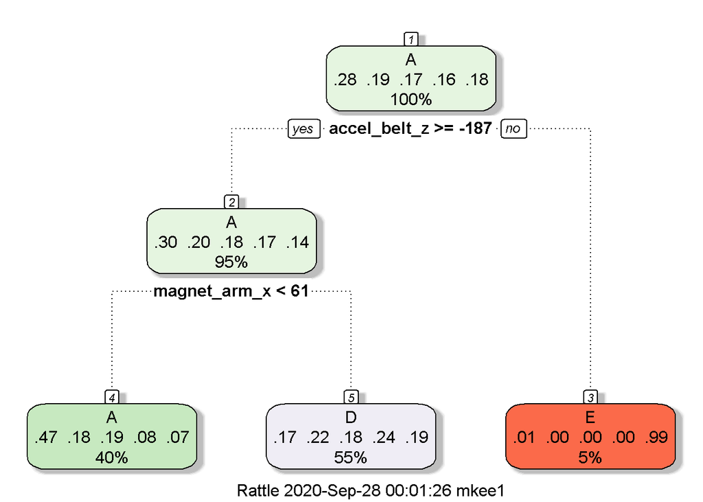

```r
# Configuring parallel process
cluster <- makeCluster(detectCores() - 1) #leave 1 core for OS
registerDoParallel(cluster)

# Setting up parallel processing parameter & 7-fold cross validation for models
fitCtrl <- trainControl(method = "cv", number = 7, allowParallel = TRUE)

# CART
modFitTree <- train(classe ~., data = training2, method = "rpart", trControl = fitCtrl)
fancyRpartPlot(modFitTree$finalModel)
```

## 4.2 **Boosted Classification Tree Using the Gradient Boosting Algorithm (GBM) Method**

```r
# Boosted CART
modFitBoost <- train(classe ~., data = training2, method = "gbm", verbose = FALSE, trControl = fitCtrl)
modFitBoost
```

```
## Stochastic Gradient Boosting
##
## 13737 samples
##    36 predictor
##     5 classes: 'A', 'B', 'C', 'D', 'E'
##
## No pre-processing
## Resampling: Cross-Validated (7 fold)
## Summary of sample sizes: 11773, 11774, 11776, 11774, 11775, 11775, ...
## Resampling results across tuning parameters:
##
##   interaction.depth  n.trees  Accuracy   Kappa
##   1                   50      0.6749632  0.5844571
##   1                  100      0.7492892  0.6809222
##   1                  150      0.7832121  0.7245215
##   2                   50      0.7907088  0.7341123
##   2                  100      0.8492387  0.8086851
##   2                  150      0.8767565  0.8437193
##   3                   50      0.8287814  0.7825268
##   3                  100      0.8817786  0.8500796
##   3                  150      0.9059474  0.8808131
##
## Tuning parameter 'shrinkage' was held constant at a value of 0.1
##
## Tuning parameter 'n.minobsinnode' was held constant at a value of 10
## Accuracy was used to select the optimal model using the largest value.
## The final values used for the model were n.trees = 150, interaction.depth =
##  3, shrinkage = 0.1 and n.minobsinnode = 10.
```

## 4.3 **Random Forest Method**

```r
# Random Forrest
modFitRF <- train(classe ~., data = training2, method = "rf", trControl = fitCtrl)
modFitRF
```

```
## Random Forest
##
## 13737 samples
##    36 predictor
##     5 classes: 'A', 'B', 'C', 'D', 'E'
##
## No pre-processing
## Resampling: Cross-Validated (7 fold)
## Summary of sample sizes: 11774, 11775, 11775, 11774, 11774, 11774, ...
## Resampling results across tuning parameters:
##
##   mtry  Accuracy   Kappa
##    2    0.9840575  0.9798257
##   19    0.9809273  0.9758651
##   36    0.9757589  0.9693256
##
## Accuracy was used to select the optimal model using the largest value.
## The final value used for the model was mtry = 2.
```

# 5 **Testing Individual Models On The Testing Data Set**

```r
# Data Conversion
testing$user_name <- as.factor(testing$user_name)
testing$cvtd_timestamp <- dmy_hm(testing$cvtd_timestamp)
testing$new_window <- as.factor(testing$new_window)
testing$num_window <- as.factor(testing$num_window)
testing$classe <- as.factor(testing$classe)

# Column check for NA values
testing %>%
  select_if(function(x) any(is.na(x))) %>%
  summarise(across(everything(), ~sum(is.na(.)))) -> SumcolumsWithNA_Test
names(SumcolumsWithNA_Test)
```

```
##  [1] "max_roll_belt"            "max_picth_belt"
##  [3] "min_roll_belt"            "min_pitch_belt"
##  [5] "amplitude_roll_belt"      "amplitude_pitch_belt"
##  [7] "var_total_accel_belt"     "avg_roll_belt"
##  [9] "stddev_roll_belt"         "var_roll_belt"
## [11] "avg_pitch_belt"           "stddev_pitch_belt"
## [13] "var_pitch_belt"           "avg_yaw_belt"
## [15] "stddev_yaw_belt"          "var_yaw_belt"
## [17] "var_accel_arm"            "avg_roll_arm"
## [19] "stddev_roll_arm"          "var_roll_arm"
## [21] "avg_pitch_arm"            "stddev_pitch_arm"
## [23] "var_pitch_arm"            "avg_yaw_arm"
## [25] "stddev_yaw_arm"           "var_yaw_arm"
## [27] "max_roll_arm"             "max_picth_arm"
## [29] "max_yaw_arm"              "min_roll_arm"
```

[output cut: 19 more lines]

```r
# Sub-setting testing set to only including predictors that are complete cases
testing2 <- testing %>% select(contains(c("_x", "_y", "_z")) & !contains("yaw") | classe)
dim(testing2)
```

```
## [1] 5885   37
```

```r
str(testing2)
```

```
## 'data.frame':    5885 obs. of  37 variables:
##  $ gyros_belt_x     : num  0.02 0.02 0.02 0 0.02 0.03 0.03 0.02 0.02 0 ...
##  $ accel_belt_x     : int  -21 -22 -20 -21 -21 -21 -21 -21 -22 -22 ...
##  $ magnet_belt_x    : int  -6 -2 1 1 -2 -4 2 0 -6 2 ...
##  $ gyros_arm_x      : num  0 0.02 0.02 0.02 0.03 -0.02 0 0 0.02 0.02 ...
##  $ accel_arm_x      : int  -289 -289 -288 -288 -289 -290 -289 -290 -291 -289 ...
##  $ magnet_arm_x     : int  -374 -372 -369 -373 -372 -364 -366 -371 -369 -372 ...
##  $ gyros_dumbbell_x : num  0 0 0 0.02 0 0 0 0 0 -0.02 ...
##  $ accel_dumbbell_x : int  -233 -234 -232 -231 -233 -234 -234 -233 -235 -232 ...
##  $ magnet_dumbbell_x: int  -554 -555 -549 -557 -554 -555 -562 -558 -556 -554 ...
##  $ gyros_forearm_x  : num  0.02 0.02 0.03 0.02 0.02 0.02 0.02 0.02 0 0.02 ...
##  $ accel_forearm_x  : int  189 193 193 192 191 193 189 192 188 192 ...
##  $ magnet_forearm_x : int  -17 -9 -16 -16 -17 -14 -4 -13 -14 -13 ...
##  $ gyros_belt_y     : num  0.02 0 0 0.02 0.02 0 0 0.02 0.02 0.02 ...
##  $ accel_belt_y     : int  2 4 2 5 3 3 4 4 3 3 ...
```

[output cut: 23 more lines]

```r
summary(testing2)
```

```
##   gyros_belt_x        accel_belt_x     magnet_belt_x     gyros_arm_x
##  Min.   :-1.040000   Min.   :-81.000   Min.   :-45.00   Min.   :-6.37000
##  1st Qu.:-0.050000   1st Qu.:-21.000   1st Qu.:  9.00   1st Qu.:-1.30000
##  Median : 0.030000   Median :-15.000   Median : 34.00   Median : 0.11000
##  Mean   :-0.006546   Mean   : -5.898   Mean   : 55.08   Mean   : 0.06167
##  3rd Qu.: 0.110000   3rd Qu.: -5.000   3rd Qu.: 58.00   3rd Qu.: 1.59000
##  Max.   : 2.020000   Max.   : 81.000   Max.   :474.00   Max.   : 4.78000
##   accel_arm_x       magnet_arm_x    gyros_dumbbell_x    accel_dumbbell_x
##  Min.   :-377.00   Min.   :-580.0   Min.   :-204.0000   Min.   :-419.0
##  1st Qu.:-243.00   1st Qu.:-303.0   1st Qu.:  -0.0300   1st Qu.: -50.0
##  Median : -44.00   Median : 290.0   Median :   0.1400   Median :  -8.0
##  Mean   : -59.58   Mean   : 192.3   Mean   :   0.1396   Mean   : -27.9
##  3rd Qu.:  86.00   3rd Qu.: 643.0   3rd Qu.:   0.3500   3rd Qu.:  11.0
##  Max.   : 437.00   Max.   : 780.0   Max.   :   1.9800   Max.   : 213.0
##  magnet_dumbbell_x gyros_forearm_x    accel_forearm_x   magnet_forearm_x
##  Min.   :-638.0    Min.   :-22.0000   Min.   :-498.00   Min.   :-1280.0
##  1st Qu.:-534.0    1st Qu.: -0.2200   1st Qu.:-180.00   1st Qu.: -616.0
##  Median :-477.0    Median :  0.0300   Median : -58.00   Median : -381.0
##  Mean   :-326.1    Mean   :  0.1503   Mean   : -61.98   Mean   : -311.4
##  3rd Qu.:-300.0    3rd Qu.:  0.5600   3rd Qu.:  75.00   3rd Qu.:  -70.0
##  Max.   : 592.0    Max.   :  3.2600   Max.   : 389.00   Max.   :  660.0
##   gyros_belt_y       accel_belt_y    magnet_belt_y    gyros_arm_y
##  Min.   :-0.64000   Min.   :-38.00   Min.   :366.0   Min.   :-3.3700
##  1st Qu.: 0.00000   1st Qu.:  3.00   1st Qu.:581.0   1st Qu.:-0.8000
##  Median : 0.02000   Median : 36.00   Median :601.0   Median :-0.2700
##  Mean   : 0.04039   Mean   : 30.38   Mean   :593.8   Mean   :-0.2657
##  3rd Qu.: 0.11000   3rd Qu.: 61.00   3rd Qu.:610.0   3rd Qu.: 0.1400
##  Max.   : 0.64000   Max.   :109.00   Max.   :673.0   Max.   : 2.8400
##   accel_arm_y       magnet_arm_y    gyros_dumbbell_y   accel_dumbbell_y
##  Min.   :-315.00   Min.   :-377.0   Min.   :-1.98000   Min.   :-176.0
##  1st Qu.: -54.00   1st Qu.: -12.0   1st Qu.:-0.14000   1st Qu.:  -9.0
##  Median :  13.00   Median : 201.0   Median : 0.05000   Median :  39.0
##  Mean   :  31.82   Mean   : 155.6   Mean   : 0.05258   Mean   :  52.1
##  3rd Qu.: 138.00   3rd Qu.: 322.0   3rd Qu.: 0.21000   3rd Qu.: 111.0
##  Max.   : 297.00   Max.   : 580.0   Max.   :52.00000   Max.   : 294.0
##  magnet_dumbbell_y gyros_forearm_y   accel_forearm_y  magnet_forearm_y
##  Min.   :-742.0    Min.   : -7.020   Min.   :-632.0   Min.   :-890.0
##  1st Qu.: 231.0    1st Qu.: -1.510   1st Qu.:  59.0   1st Qu.:  -2.0
##  Median : 312.0    Median :  0.030   Median : 199.0   Median : 589.0
##  Mean   : 222.7    Mean   :  0.102   Mean   : 162.7   Mean   : 378.7
```

[output cut: 15 more lines]

```
##  Max.   : 227.00   Max.   : 682.0   Max.   :317.0000   Max.   : 318.00
##  magnet_dumbbell_z gyros_forearm_z   accel_forearm_z   magnet_forearm_z
##  Min.   :-238.00   Min.   : -4.280   Min.   :-391.00   Min.   :-973.0
##  1st Qu.: -46.00   1st Qu.: -0.180   1st Qu.:-181.00   1st Qu.: 193.0
##  Median :  11.00   Median :  0.080   Median : -37.00   Median : 510.0
##  Mean   :  45.27   Mean   :  0.169   Mean   : -55.05   Mean   : 394.2
##  3rd Qu.:  96.00   3rd Qu.:  0.490   3rd Qu.:  26.00   3rd Qu.: 651.0
##  Max.   : 451.00   Max.   :231.000   Max.   : 291.00   Max.   :1070.0
##  classe
##  A:1674
##  B:1139
##  C:1026
##  D: 964
##  E:1082
##
```

```r
# Checking to see if any of the co-variants have zero or near zero variability
nzv <- nearZeroVar(testing2, saveMetrics = TRUE)
nzv
```

```
##                   freqRatio percentUnique zeroVar   nzv
## gyros_belt_x       1.091811    1.81818182   FALSE FALSE
## accel_belt_x       1.016878    2.51486831   FALSE FALSE
## magnet_belt_x      1.064516    4.11214953   FALSE FALSE
## gyros_arm_x        1.006944   10.12744265   FALSE FALSE
## accel_arm_x        1.070175   12.01359388   FALSE FALSE
## magnet_arm_x       1.178571   20.57774002   FALSE FALSE
## gyros_dumbbell_x   1.022222    3.55140187   FALSE FALSE
## accel_dumbbell_x   1.141414    6.04927782   FALSE FALSE
## magnet_dumbbell_x  1.037037   15.03823280   FALSE FALSE
## gyros_forearm_x    1.050955    4.16312659   FALSE FALSE
## accel_forearm_x    1.172414   12.74426508   FALSE FALSE
## magnet_forearm_x   1.071429   20.78164826   FALSE FALSE
## gyros_belt_y       1.130115    1.00254885   FALSE FALSE
## accel_belt_y       1.109375    1.97111300   FALSE FALSE
## magnet_belt_y      1.147208    4.19711130   FALSE FALSE
## gyros_arm_y        1.605839    5.77740017   FALSE FALSE
## accel_arm_y        1.290323    8.42820731   FALSE FALSE
## magnet_arm_y       1.142857   13.62786746   FALSE FALSE
## gyros_dumbbell_y   1.359116    3.99320306   FALSE FALSE
## accel_dumbbell_y   1.057971    7.08581138   FALSE FALSE
## magnet_dumbbell_y  1.057692   12.62531861   FALSE FALSE
## gyros_forearm_y    1.126126   11.29991504   FALSE FALSE
## accel_forearm_y    1.030303   15.31011045   FALSE FALSE
## magnet_forearm_y   1.142857   26.28717077   FALSE FALSE
## gyros_belt_z       1.054369    2.42990654   FALSE FALSE
## accel_belt_z       1.130612    4.36703483   FALSE FALSE
## magnet_belt_z      1.028369    6.30416313   FALSE FALSE
## gyros_arm_z        1.233766    3.38147833   FALSE FALSE
## accel_arm_z        1.026316   11.75870858   FALSE FALSE
## magnet_arm_z       1.058824   19.54120646   FALSE FALSE
## gyros_dumbbell_z   1.062500    2.87170773   FALSE FALSE
## accel_dumbbell_z   1.141176    6.37213254   FALSE FALSE
## magnet_dumbbell_z  1.240741   10.31435854   FALSE FALSE
## gyros_forearm_z    1.227941    4.28207307   FALSE FALSE
## accel_forearm_z    1.057692    8.54715378   FALSE FALSE
## magnet_forearm_z   1.095238   23.05862362   FALSE FALSE
## classe             1.469710    0.08496177   FALSE FALSE
```

```r
# Performing predictions on sub-set of the testing data set using the models above & using confusion matrices to assess accuracy
predTree <- predict(modFitTree, testing2)
confusionMatrix(predTree, testing2$classe)
```

```
## Confusion Matrix and Statistics
##
##           Reference
## Prediction    A    B    C    D    E
##          A 1094  433  476  196  162
##          B    0    0    0    0    0
##          C    0    0    0    0    0
##          D  578  706  550  768  623
##          E    2    0    0    0  297
##
## Overall Statistics
##
##                Accuracy : 0.3669
##                  95% CI : (0.3545, 0.3793)
##     No Information Rate : 0.2845
##     P-Value [Acc > NIR] : < 2.2e-16
##
##                   Kappa : 0.1953
##
##  Mcnemar's Test P-Value : NA
##
## Statistics by Class:
##
##                      Class: A Class: B Class: C Class: D Class: E
## Sensitivity            0.6535   0.0000   0.0000   0.7967  0.27449
## Specificity            0.6991   1.0000   1.0000   0.5007  0.99958
## Pos Pred Value         0.4634      NaN      NaN   0.2381  0.99331
## Neg Pred Value         0.8354   0.8065   0.8257   0.9263  0.85947
## Prevalence             0.2845   0.1935   0.1743   0.1638  0.18386
## Detection Rate         0.1859   0.0000   0.0000   0.1305  0.05047
## Detection Prevalence   0.4012   0.0000   0.0000   0.5480  0.05081
## Balanced Accuracy      0.6763   0.5000   0.5000   0.6487  0.63704
```

```r
predBoost <- predict(modFitBoost, testing2)
confusionMatrix(predBoost, testing2$classe)
```

```
## Confusion Matrix and Statistics
##
##           Reference
## Prediction    A    B    C    D    E
##          A 1617   82   26   24   12
##          B   11  962   48    7   29
##          C   22   71  923   65   24
##          D   23   14   26  847   23
##          E    1   10    3   21  994
##
## Overall Statistics
##
##                Accuracy : 0.9079
##                  95% CI : (0.9002, 0.9152)
##     No Information Rate : 0.2845
##     P-Value [Acc > NIR] : < 2.2e-16
##
##                   Kappa : 0.8833
##
##  Mcnemar's Test P-Value : < 2.2e-16
##
## Statistics by Class:
##
##                      Class: A Class: B Class: C Class: D Class: E
## Sensitivity            0.9659   0.8446   0.8996   0.8786   0.9187
## Specificity            0.9658   0.9800   0.9625   0.9825   0.9927
## Pos Pred Value         0.9182   0.9101   0.8353   0.9078   0.9660
## Neg Pred Value         0.9862   0.9633   0.9785   0.9764   0.9819
## Prevalence             0.2845   0.1935   0.1743   0.1638   0.1839
## Detection Rate         0.2748   0.1635   0.1568   0.1439   0.1689
## Detection Prevalence   0.2992   0.1796   0.1878   0.1585   0.1749
## Balanced Accuracy      0.9659   0.9123   0.9311   0.9306   0.9557
```

```r
predRF <- predict(modFitRF, testing2)
confusionMatrix(predRF, testing2$classe)
```

```
## Confusion Matrix and Statistics
##
##           Reference
## Prediction    A    B    C    D    E
##          A 1669   14    1    1    0
##          B    3 1114   13    0    0
##          C    0   11 1012   25    0
##          D    1    0    0  938    2
##          E    1    0    0    0 1080
##
## Overall Statistics
##
##                Accuracy : 0.9878
##                  95% CI : (0.9846, 0.9904)
##     No Information Rate : 0.2845
##     P-Value [Acc > NIR] : < 2.2e-16
##
##                   Kappa : 0.9845
##
##  Mcnemar's Test P-Value : NA
##
## Statistics by Class:
##
##                      Class: A Class: B Class: C Class: D Class: E
## Sensitivity            0.9970   0.9781   0.9864   0.9730   0.9982
## Specificity            0.9962   0.9966   0.9926   0.9994   0.9998
## Pos Pred Value         0.9905   0.9858   0.9656   0.9968   0.9991
## Neg Pred Value         0.9988   0.9947   0.9971   0.9947   0.9996
## Prevalence             0.2845   0.1935   0.1743   0.1638   0.1839
## Detection Rate         0.2836   0.1893   0.1720   0.1594   0.1835
## Detection Prevalence   0.2863   0.1920   0.1781   0.1599   0.1837
## Balanced Accuracy      0.9966   0.9873   0.9895   0.9862   0.9990
```

```r
ONSAccuracyTree <- confusionMatrix(predTree, testing2$classe)$overall['Accuracy']
ONSAccuracyBoost <- confusionMatrix(predBoost, testing2$classe)$overall['Accuracy']
ONSAccuracyRF <- confusionMatrix(predRF, testing2$classe)$overall['Accuracy']
```

# 6 **Ensembling Method: Model Stacking Approach & Testing**

```r
# Creating data frame with different predictors obtained from the individual models above
predDF <- data.frame(predTree, predBoost, predRF, classe=testing2$classe)

# Training the model
combModFit <- train(classe ~., data = predDF, method = "rf", trControl = fitCtrl)

# Predicting new values on the data frame
combPred <- predict(combModFit, predDF)
confusionMatrix(combPred, predDF$classe)
```

```
## Confusion Matrix and Statistics
##
##           Reference
## Prediction    A    B    C    D    E
##          A 1669   14    1    1    0
##          B    3 1114   13    0    0
##          C    0   11 1012   25    0
##          D    1    0    0  938    2
##          E    1    0    0    0 1080
##
## Overall Statistics
##
##                Accuracy : 0.9878
##                  95% CI : (0.9846, 0.9904)
##     No Information Rate : 0.2845
##     P-Value [Acc > NIR] : < 2.2e-16
##
##                   Kappa : 0.9845
##
##  Mcnemar's Test P-Value : NA
##
## Statistics by Class:
##
##                      Class: A Class: B Class: C Class: D Class: E
## Sensitivity            0.9970   0.9781   0.9864   0.9730   0.9982
## Specificity            0.9962   0.9966   0.9926   0.9994   0.9998
## Pos Pred Value         0.9905   0.9858   0.9656   0.9968   0.9991
## Neg Pred Value         0.9988   0.9947   0.9971   0.9947   0.9996
## Prevalence             0.2845   0.1935   0.1743   0.1638   0.1839
## Detection Rate         0.2836   0.1893   0.1720   0.1594   0.1835
## Detection Prevalence   0.2863   0.1920   0.1781   0.1599   0.1837
## Balanced Accuracy      0.9966   0.9873   0.9895   0.9862   0.9990
```

```r
# Using confusion matrix to assess accuracy of the model stacking approach
ONSAccuracyMS <- confusionMatrix(combPred, predDF$classe)$overall['Accuracy']
```

Prediction accuracy was chosen to be the prediction error measure of choice. Therefore, the accuracy for all four prediction methods were compared to determine the most accurate model for predicting the manner in which the participants did the exercise of interest. After evaluating each modeling method on the test data set, the estimated out-of-sample error, quantified via the accuracy of each of the modeling methods, were:

- Classification Tree Using RPart Method: 0.3668649
- Boosted Classification Tree Using the Gradient Boosting Algorithm (GBM) Method: 0.9079014
- Random Forest Method: 0.9877655
- Model Stacking Ensembling Method: 0.9877655

Based off the above, one can observe that the best prediction result was provided by either the Random Forest Method or the Model Stacking Ensembling Method. Since both methods yielded the same out-of-sample accuracy, the Random Forest Model was used on the validation data set. Both the code & the results are presented below.

# 7 **Testing Individual Models On The Validation Data Set**

```r
# Data Conversion
validation$user_name <- as.factor(validation$user_name)
validation$cvtd_timestamp <- dmy_hm(validation$cvtd_timestamp)
validation$new_window <- as.factor(validation$new_window)
validation$num_window <- as.factor(validation$num_window)

# Column check for NA values
validation %>%
  select_if(function(x) any(is.na(x))) %>%
  summarise(across(everything(), ~sum(is.na(.)))) -> SumcolumsWithNA_Valid
names(SumcolumsWithNA_Valid)
```

```
##   [1] "kurtosis_roll_belt"       "kurtosis_picth_belt"
##   [3] "kurtosis_yaw_belt"        "skewness_roll_belt"
##   [5] "skewness_roll_belt.1"     "skewness_yaw_belt"
##   [7] "max_roll_belt"            "max_picth_belt"
##   [9] "max_yaw_belt"             "min_roll_belt"
##  [11] "min_pitch_belt"           "min_yaw_belt"
##  [13] "amplitude_roll_belt"      "amplitude_pitch_belt"
##  [15] "amplitude_yaw_belt"       "var_total_accel_belt"
##  [17] "avg_roll_belt"            "stddev_roll_belt"
##  [19] "var_roll_belt"            "avg_pitch_belt"
##  [21] "stddev_pitch_belt"        "var_pitch_belt"
##  [23] "avg_yaw_belt"             "stddev_yaw_belt"
##  [25] "var_yaw_belt"             "var_accel_arm"
##  [27] "avg_roll_arm"             "stddev_roll_arm"
##  [29] "var_roll_arm"             "avg_pitch_arm"
```

[output cut: 35 more lines]

```r
# Sub-setting validation set to only including predictors that are complete cases
validation2 <- validation %>% select(contains(c("_x", "_y", "_z")) & !contains("yaw"))
dim(validation2)
```

```
## [1] 20 36
```

```r
str(validation2)
```

```
## 'data.frame':    20 obs. of  36 variables:
##  $ gyros_belt_x     : num  -0.5 -0.06 0.05 0.11 0.03 0.1 -0.06 -0.18 0.1 0.14 ...
##  $ accel_belt_x     : int  -38 -13 1 46 -8 -11 -14 -10 -15 -25 ...
##  $ magnet_belt_x    : int  -13 43 29 169 33 31 50 39 -6 10 ...
##  $ gyros_arm_x      : num  -1.65 -1.17 2.1 0.22 -1.96 0.02 2.36 -3.71 0.03 0.26 ...
##  $ accel_arm_x      : int  16 -290 -341 -238 -197 -26 99 -98 -287 -301 ...
##  $ magnet_arm_x     : int  -326 -325 -264 -173 -170 396 702 535 -367 -420 ...
##  $ gyros_dumbbell_x : num  0.64 0.34 0.39 0.1 0.29 -0.59 0.34 0.37 0.03 0.42 ...
##  $ accel_dumbbell_x : int  21 -153 -141 -51 -18 -138 -145 -140 0 -7 ...
##  $ magnet_dumbbell_x: int  523 -502 -506 -576 -424 -543 -484 -515 -519 -531 ...
##  $ gyros_forearm_x  : num  0.74 1.12 0.18 1.38 -0.75 -0.88 -0.53 0.63 0.03 0.02 ...
##  $ accel_forearm_x  : int  -110 212 154 -92 131 230 -192 -151 195 -212 ...
##  $ magnet_forearm_x : int  -714 -237 -51 -233 375 -300 -678 -109 0 -403 ...
##  $ gyros_belt_y     : num  -0.02 -0.02 0.02 0.11 0.02 0.05 0 -0.02 0 0.11 ...
##  $ accel_belt_y     : int  69 11 -1 45 4 -16 2 -2 1 63 ...
```

[output cut: 22 more lines]

```r
summary(validation2)
```

```
##   gyros_belt_x     accel_belt_x    magnet_belt_x     gyros_arm_x
##  Min.   :-0.500   Min.   :-48.00   Min.   :-13.00   Min.   :-3.710
##  1st Qu.:-0.070   1st Qu.:-19.00   1st Qu.:  5.50   1st Qu.:-0.645
##  Median : 0.020   Median :-13.00   Median : 33.50   Median : 0.020
##  Mean   :-0.045   Mean   :-13.50   Mean   : 35.15   Mean   : 0.077
##  3rd Qu.: 0.070   3rd Qu.: -8.75   3rd Qu.: 46.25   3rd Qu.: 1.248
##  Max.   : 0.240   Max.   : 46.00   Max.   :169.00   Max.   : 3.660
##   accel_arm_x      magnet_arm_x     gyros_dumbbell_x  accel_dumbbell_x
##  Min.   :-341.0   Min.   :-428.00   Min.   :-1.0300   Min.   :-159.00
##  1st Qu.:-277.0   1st Qu.:-373.75   1st Qu.: 0.1600   1st Qu.:-140.25
##  Median :-194.5   Median :-265.00   Median : 0.3600   Median : -19.00
##  Mean   :-134.6   Mean   : -38.95   Mean   : 0.2690   Mean   : -47.60
##  3rd Qu.:   5.5   3rd Qu.: 250.50   3rd Qu.: 0.4625   3rd Qu.:  15.75
##  Max.   : 106.0   Max.   : 750.00   Max.   : 1.0600   Max.   : 185.00
##  magnet_dumbbell_x gyros_forearm_x   accel_forearm_x  magnet_forearm_x
##  Min.   :-576.0    Min.   :-1.0600   Min.   :-212.0   Min.   :-714.0
##  1st Qu.:-528.0    1st Qu.:-0.5850   1st Qu.:-114.8   1st Qu.:-427.2
##  Median :-508.5    Median : 0.0200   Median :  86.0   Median :-189.5
##  Mean   :-304.2    Mean   :-0.0200   Mean   :  38.8   Mean   :-159.2
##  3rd Qu.:-317.0    3rd Qu.: 0.2925   3rd Qu.: 166.2   3rd Qu.:  41.5
##  Max.   : 523.0    Max.   : 1.3800   Max.   : 232.0   Max.   : 532.0
##   gyros_belt_y     accel_belt_y    magnet_belt_y    gyros_arm_y
##  Min.   :-0.050   Min.   :-16.00   Min.   :566.0   Min.   :-2.0900
##  1st Qu.:-0.005   1st Qu.:  2.00   1st Qu.:578.5   1st Qu.:-0.6350
##  Median : 0.000   Median :  4.50   Median :600.5   Median :-0.0400
##  Mean   : 0.010   Mean   : 18.35   Mean   :601.5   Mean   :-0.1595
##  3rd Qu.: 0.020   3rd Qu.: 25.50   3rd Qu.:631.2   3rd Qu.: 0.2175
##  Max.   : 0.110   Max.   : 72.00   Max.   :638.0   Max.   : 1.8500
##   accel_arm_y      magnet_arm_y    gyros_dumbbell_y  accel_dumbbell_y
##  Min.   :-65.00   Min.   :-307.0   Min.   :-1.1100   Min.   :-30.00
##  1st Qu.: 52.25   1st Qu.: 205.2   1st Qu.:-0.2100   1st Qu.:  5.75
##  Median :112.00   Median : 291.0   Median : 0.0150   Median : 71.50
##  Mean   :103.10   Mean   : 239.4   Mean   : 0.0605   Mean   : 70.55
##  3rd Qu.:168.25   3rd Qu.: 358.8   3rd Qu.: 0.1450   3rd Qu.:151.25
##  Max.   :245.00   Max.   : 474.0   Max.   : 1.9100   Max.   :166.00
##  magnet_dumbbell_y gyros_forearm_y   accel_forearm_y  magnet_forearm_y
##  Min.   :-558.0    Min.   :-5.9700   Min.   :-331.0   Min.   :-787.0
##  1st Qu.: 259.5    1st Qu.:-1.2875   1st Qu.:   8.5   1st Qu.:-328.8
##  Median : 316.0    Median : 0.0350   Median : 138.0   Median : 487.0
##  Mean   : 189.3    Mean   :-0.0415   Mean   : 125.3   Mean   : 191.8
```

[output cut: 8 more lines]

```
##  Max.   : 0.0500   Max.   :  49.00   Max.   :-291.0   Max.   : 1.1300
##   accel_arm_z       magnet_arm_z    gyros_dumbbell_z accel_dumbbell_z
##  Min.   :-404.00   Min.   :-499.0   Min.   :-1.180   Min.   :-221.0
##  1st Qu.:-128.50   1st Qu.: 403.0   1st Qu.:-0.485   1st Qu.:-192.2
##  Median : -83.50   Median : 476.5   Median :-0.280   Median :  -3.0
##  Mean   : -87.85   Mean   : 369.8   Mean   :-0.266   Mean   : -60.0
##  3rd Qu.: -27.25   3rd Qu.: 517.0   3rd Qu.:-0.165   3rd Qu.:  76.5
##  Max.   :  93.00   Max.   : 633.0   Max.   : 1.100   Max.   : 100.0
##  magnet_dumbbell_z gyros_forearm_z   accel_forearm_z  magnet_forearm_z
##  Min.   :-164.00   Min.   :-1.2600   Min.   :-282.0   Min.   :-32.0
##  1st Qu.: -33.00   1st Qu.:-0.0975   1st Qu.:-199.0   1st Qu.:275.2
##  Median :  49.50   Median : 0.2300   Median :-148.5   Median :491.5
##  Mean   :  71.40   Mean   : 0.2610   Mean   : -93.7   Mean   :460.2
##  3rd Qu.:  96.25   3rd Qu.: 0.7625   3rd Qu.: -31.0   3rd Qu.:661.5
##  Max.   : 368.00   Max.   : 1.8000   Max.   : 179.0   Max.   :884.0
```

```r
# Checking to see if any of the co-variants have zero or near zero variability
nzv <- nearZeroVar(validation2, saveMetrics = TRUE)
nzv
```

```
##                   freqRatio percentUnique zeroVar   nzv
## gyros_belt_x           1.50            70   FALSE FALSE
## accel_belt_x           1.00            85   FALSE FALSE
## magnet_belt_x          1.00           100   FALSE FALSE
## gyros_arm_x            2.00            95   FALSE FALSE
## accel_arm_x            2.00            95   FALSE FALSE
## magnet_arm_x           1.00           100   FALSE FALSE
## gyros_dumbbell_x       1.00            90   FALSE FALSE
## accel_dumbbell_x       1.00           100   FALSE FALSE
## magnet_dumbbell_x      1.00           100   FALSE FALSE
## gyros_forearm_x        1.00            90   FALSE FALSE
## accel_forearm_x        1.00           100   FALSE FALSE
## magnet_forearm_x       1.00           100   FALSE FALSE
## gyros_belt_y           2.25            30   FALSE FALSE
## accel_belt_y           1.50            75   FALSE FALSE
## magnet_belt_y          1.50            80   FALSE FALSE
## gyros_arm_y            2.00            95   FALSE FALSE
## accel_arm_y            1.00           100   FALSE FALSE
## magnet_arm_y           2.00            95   FALSE FALSE
## gyros_dumbbell_y       1.00            80   FALSE FALSE
## accel_dumbbell_y       3.00            90   FALSE FALSE
## magnet_dumbbell_y      1.00           100   FALSE FALSE
## gyros_forearm_y        1.00           100   FALSE FALSE
## accel_forearm_y        1.00           100   FALSE FALSE
## magnet_forearm_y       1.00           100   FALSE FALSE
## gyros_belt_z           2.50            65   FALSE FALSE
## accel_belt_z           1.00            85   FALSE FALSE
## magnet_belt_z          1.50            80   FALSE FALSE
## gyros_arm_z            1.00            90   FALSE FALSE
## accel_arm_z            1.00           100   FALSE FALSE
## magnet_arm_z           1.00           100   FALSE FALSE
## gyros_dumbbell_z       4.00            85   FALSE FALSE
## accel_dumbbell_z       2.00            95   FALSE FALSE
## magnet_dumbbell_z      2.00            95   FALSE FALSE
## gyros_forearm_z        1.00           100   FALSE FALSE
## accel_forearm_z        1.00           100   FALSE FALSE
## magnet_forearm_z       1.00           100   FALSE FALSE
```

```r
# Performing predictions on sub-set of the validation data set using the models above & using confusion matrix to assess accuracy
predValidRF <- predict(modFitRF, validation2)
dt <- data.frame(validation$user_name, classe=predValidRF)
dt
```

```
##    validation.user_name classe
## 1                 pedro      B
## 2                jeremy      A
## 3                jeremy      B
## 4                adelmo      A
## 5                eurico      A
## 6                jeremy      E
## 7                jeremy      D
## 8                jeremy      B
## 9              carlitos      A
## 10              charles      A
## 11             carlitos      B
## 12               jeremy      C
## 13               eurico      B
## 14               jeremy      A
## 15               jeremy      E
## 16               eurico      E
## 17                pedro      A
## 18             carlitos      B
## 19                pedro      B
## 20               eurico      B
```

```r
# Explicitly shut down the cluster
stopCluster(cluster)
registerDoSEQ()
```

# 8 **Conclusion**

In summary, the purpose of this task was to use accelerometer data from various health-fitness activity trackers to quantify how well 6 participants perform one set of 10 repetitions of the Unilateral Dumbbell Biceps Curl in five different fashions. The accelerometers for this experiment were positioned on the belt, forearm, arm, and dumbbell. The “classe” variable within the data set is the term that is used to indicate the manner in which the exercise was perform by the 6 participants.

Four classification models were trained & evaluated for prediction performance. The respective, estimated out-of-sample accuracy results are summarized below.

- Classification Tree Using RPart Method: 0.3668649
- Boosted Classification Tree Using the Gradient Boosting Algorithm (GBM) Method: 0.9079014
- Random Forest Method: 0.9877655
- Model Stacking Ensembling Method: 0.9877655

Both the Random Forest Method and the Model Stacking Ensembling Method yielded the same out-of-sample accuracy. So therefore, the Random Forest Model was used on the validation data set and yielded the following results:

```r
dt
```

```
##    validation.user_name classe
## 1                 pedro      B
## 2                jeremy      A
## 3                jeremy      B
## 4                adelmo      A
## 5                eurico      A
## 6                jeremy      E
## 7                jeremy      D
## 8                jeremy      B
## 9              carlitos      A
## 10              charles      A
## 11             carlitos      B
## 12               jeremy      C
## 13               eurico      B
## 14               jeremy      A
## 15               jeremy      E
## 16               eurico      E
## 17                pedro      A
## 18             carlitos      B
## 19                pedro      B
## 20               eurico      B
```

[^1]: Velloso, E.; Bulling, A.; Gellersen, H.; Ugulino, W.; Fuks, H. Qualitative Activity Recognition of Weight Lifting Exercises. Proceedings of 4th International Conference in Cooperation with SIGCHI (Augmented Human ’13) . Stuttgart, Germany: ACM SIGCHI, 2013.